# Individual-based Integral Projection Models: The role of size-structure on extinction risk and establishment success

Sebastian Schreiber and Noam Ross

April 8, 2015

$\def\N{\mathbb N}$ $\def\R{\mathbb R}$ $\def\P{\mathbb P}$ $\def\N{\mathbb N}$ $\def\S{\mathcal S}$ $\def\n{\mathbf n}$ $\def\s{\mathbb s}$ $\def\x{\mathbf x}$ $\def\y{\mathbf y}$ $\def\o{\%*\%}$

## The General Models and Methods

### The Individual Based IPM

We consider an individual-based model where the set of all possible individual states (e.g. age, size, etc.) lies in a compact metric space $X$. For example, for the standard size-structured IPM, $X=[a,b]$ corresponds to the range of sizes measured in the field. For models with a mixture of age and size stucture, $X$ could be given by $\{1,\dots,T\}\times [a,b]$ where $T$ corresponds to the maximal age of an individual.

As we consider finite populations, the state of the population at any point of the time is characterized by the different sizes $(x_1,x_2,\dots, x_k)$ of individuals within the population and how many individuals there are of each these sizes $(n_1,n_2,\dots, n_k)$. Specifically, if there $n_1$ individuals of size $x_1$, $n_2$ individuals of size $x_2$,…, $n_k$ individuals of size $x_k$, then the state of the population is given by $(n_1,n_2,\dots, n_k; x_1,x_2,\dots, x_k)$. Following Harris (1963), the set of all possible population states is $\S= \{(\n,\x)=(n_1,\dots, n_k, x_1\dots , x_k): k,n_i\in \N, x_i \in X\} \cup \{0\}$ where $\N=\{1,2,3,\dots\}$ denotes the natural numbers and $0$ is the extinction state corresponding to no individuals in the population.

Let $\s_t=( \n, \x)\in \S$ be the population state at time $t$. The dynamics of $\s_t$ are determined by a set of probabilistic rules that determine the contribution of each individual in the population to the population in next time step $t+1$. These “contributions” may correspond to an individual surviving and changing state (e.g. growing in size), or having offspring. Consistent with standard branching process theory, each individual in the population updates independent of all other individuals. The update rule for an individual of size $x$ is given by a probability measure $m(x,d\s)$ on the state space $\S$. Specically, the probability an individual in state $x$ contributes $\s$ individuals to the population in the next time step where $\s$ lies in a subset $A\subset \S$ equals $\P[\s_1\in A| \s_0 =(1,x)]=\int_A m(x,d\s)$ where the left hand side reads “the probability the population state lies $A$ at time $t=1$ after initially having only one individual in state $x$.”

If the population state is currently $\s_t=(n_1,\dots,n_k,x_1,\dots,x_k)$, then the state $\s_{t+1}$ is determined as follows:

1. for each of the $n_1$ individuals in state $x_1$, randomly and indepedently choose the number of replacement individuals from distribution $m(x_1,d\,\s)$.
2. repeat step 1. for the types $x_2,\dots, x_k$.
3. determine the new population state by identifying the states of all individuals and counting the total number of individuals in each of these states.

This iterative algorithm can be used to create individual based simulations of the individual based IPM. As with any branching process, stochastic realizations of this process, with probability one, either go to extinction in finite time, or the population size grows without bound.

### Probability generating functionals and extinction probabilities

As with multiple-type branching processes, we can characterize the probabilistic state of the system using probability generating functionals $\Psi$ (pgfs). Our approach differs from Harris (1963) who used moment generating functionals instead. Unlike mgfs, the pgfs allow us to compute how extinction probabilties change in time as well as compute asymptotic extinction probabilities.

To define the pgf $\Psi$, we introduce the following notation: given a continuous function $h:X\to\R$ and $\s\in \S$, let $h^\s= \left\{ \begin{array}{cc} \prod_{i=1}^k h(x_i)^{n_i}&\mbox{ if }\s=(n_1,\dots,n_k,x_1,\dots,x_k)\\ 1 &\mbox{ if }\s=0. \end{array} \right.$ We define the pgf by $\Psi(h)(x)=\int h^\s \,m(x,d\s).\tag{*}$ In words, $\Psi(h)(x)$ corresponds to the expected value of $h^\s$ due to the contributions of individuals in the next time step from an individual in state $x$. This requires integrating over all possible populations states in the next time step.

The utility of $\Psi$ for computing extinction probabilities follows from two facts. The first fact stems immediately from the definition: if $h_0$ is the zero function (i.e. $h_0(x)=0$ for all $x$), then $\Psi(h_0)(x)=\int 1 \,m(d\s,x)= \P[\s_1=0|\s_0=(1,x)]$ is the probability the population goes extinct in one time step given that initially it consisted of one individual is state $x$. For the second fact, we define $\Psi^t(h)=\underbrace{\Psi(\Psi(\dots \Psi}_{\mbox{$t$ times}}(h)\dots))$ to be the $t$-fold composition of $\Psi$ with itself. We claim that $\Psi^t(h_0)(x)=\P[\s_t=0|\s_0=(1,x)]=:E_t(x)\tag{**}$ is the probability of extinction by time $t$ given that the population initially consisted of one individual in state $x$. To see why this fact is true, we argue by induction. The first fact proves that the statement holds for $t=1$. Now suppose the assertion holds for $t$, we will show it holds for $t+1$. On the event that $\s_1=(n_1,\dots,n_k,x_1,\dots,x_k)$ is the population state at time $1$, extinction occurs by time $t+1$ only if each of the lineages of the $n_1+\dots +n_k$ individuals go extinct in the next $t$ time steps. As the fates of these lineages are independent of one another, it follows that $\begin{aligned} \P[s_{t+1}=0|\s_0=(1,x),\s_1=(n_1,\dots,n_k,x_1,\dots,x_k)]&= \prod_{i=1}^k \P[\s_t=0|\s_0=(1,x_i)]^{n_i}\\ &=\prod_{i=1}^k\left(\Psi^t(h_0)(x_i)\right)^{n_i}=\Psi^t(h_0)^{\s_1} \end{aligned}$ where the second equality follows from our inductive hypothesis. By the law of total probability $\P[s_{t+1}=0|\s_0=(1,x)]=\int [\Psi^t(h_0)]^\s \,m(d\s,x)$ which, by definition, equals $\Psi^{t+1}(0)(x)$ as claimed.

Hence, equation (**) can be used to compute extinction probabilities iteratively. Furthremore, as individuals update independent of one another, the probability of the population going extinct by time $t$ for any initial condition $\s=(n_1,\dots,n_k,x_1,\dots,x_k)$ equals $\P[\s_t=0|\s_0=\s]=E_t^\s.$ These analytic expressions allow us to efficiently compute extinction probabilities by constructing a numerical approximation of the pgf and iterating it with an initial condition of a zero vector which corresponds to the numerical approximation of the zero function.

As $E_0(x)\le E_1(x),\le E_2(x)\dots$ for any $x\in X$ and $E_t(x)\le 1$ for all $t$, there is a well defined limit corresponding to the probability of eventual extinction: $E_\infty(x):=\lim_{t\to\infty} E_t(x).$ Using moment generating functionals and under suitable technical hypotheses, Harris showed that $E_\infty(x)<1$ for all $x$ if the dominant eigenvalue of the mean-field IPM is greater than one, and $E_\infty(x)=1$ for all $x$ otherwise.

## An Illustration with an Endangered Plant Species

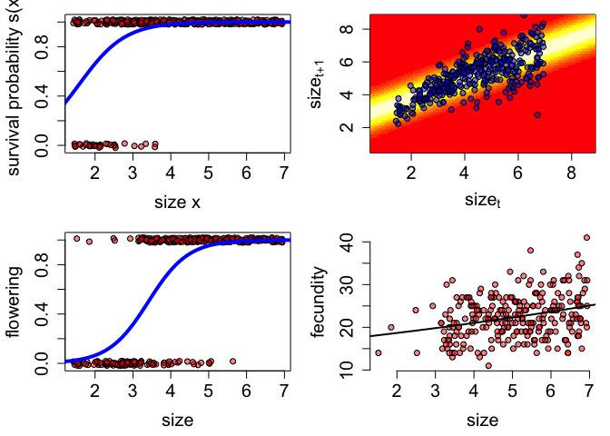

```r
# The following code loads the functions for the mean field IPM:

rm (list = ls ())
load("IPMs.Rdata")
g=function(y,x)Growth(y,x)
s=function(x)Survival(x)
f=function(x)fecundity(x)*establishment.prob
pf=function(x)1
e=function(y)dnorm(y,mean=recruit.size.mean,sd=recruit.size.sd)
par(mfrow=c(2,2),mar=c(4.5,4.5,1,1),cex.lab=1.5,cex.axis=1.5)
plot(data$size,jitter(data$surv,factor=0.1),pch=21,bg=rgb(1,0,0,0.5),xlab="size x",ylab="survival probability s(x)")
lines(xs,Survival(xs),lwd=4,col="blue")
image(xs,xs,t(outer(xs,xs,Growth)),xlab=expression(size[t]),ylab=expression(size[t+1]))
points(data$size,data$sizeNext,pch=21,bg=rgb(0,0,1,0.5))
plot(data$size,jitter(data$fec.flower,factor=0.1),pch=21,bg=rgb(1,0,0,0.5),xlab="size",ylab="flowering")
lines(xs,flowering(xs),lwd=4,col="blue")
plot(size.temp,seed.temp,pch=21,bg=rgb(1,0,0,0.5),bty="n",xlab="size",ylab="fecundity")
lines(xs,fecundity(xs),lwd=2)
```

The kernels $s(x)$, $G(y,x)$, $p(x)$ and $e(x)$ provide us with all the information that the individual-based IPMs requires for probabilistic updating individuals for survival, growth, flowering or not, and size at first census. The fecundity kernel $f(y)$, however, only specifies the mean number of offspring produced, but for an individual-based IPM, we need the distribution of the number of offspring produced by an individual. Fortunately, when using GLMs for the fecundity data, this extra information comes for free. For example, the fecundity data was modeled using a Poisson family for the GLM. In which case, the mean number $f(x)$ of offspring also specifies the distribution. More generaly, one might use multi-parameter distributions such as a zero inflated poisson or a negative binomial in which case parameters beyond the mean are needed to specify the distribution of offspring number.